# Efecto del estrés hídrico sobre el desarrollo de *Phaseolus vulgaris*

Ph D. Mario Hernández Guzmán & Ph D. Valentín Pérez Hernández

2022-08-18

### Setting up the environment

```r
options(digits = 4, scipen = 100000)
set.seed(9999)
knitr::opts_chunk$set(echo = TRUE)
```

## 1. Cargamos paqueterías

```r
library(ggplot2) # gráficos
library(car)     # estadística
library(Rmisc)   # media, sd, se y ci
library(nortest) # estadísticos
library(dplyr)   # manipulación de bases de datos
library(tidyr)   # manipulación de datos
library(lme4)    # modelos lineales
library(lmerTest)# modelos lineales
```

## 2. Cargamos los datos de cada equipo

En este caso, creamoos una base de datos única que incluye los datos de los cinco equipos.

```r
## cargamos los dataframes de cada equipo
data <- readxl::read_excel('../data/database_all.xlsx', sheet = 1) %>%
    as.data.frame()
```

Revisamos de manera general las dimensiones de nuestra base de datos. Se incluyern dos columnas nuevas. `team` y `fertilizer` que se usarán para los análisis estadisticos posteriorente.

```r
## resumen de las características de la base de datos
dim(data) # cuenta con 147 filas (observaciones), y 13 columnas (variables)
```

```
## [1] 147  14
```

```r
str(data) # cuenta con variables numéricas, y categóricas (chr)
```

```
## 'data.frame':    147 obs. of  14 variables:
##  $ SampleID  : num  1 2 3 4 5 6 7 8 9 10 ...
##  $ label     : chr  "LM1R1" "LM1R2" "LM1R3" "LM2R1" ...
##  $ humedad   : chr  "low" "low" "low" "low" ...
##  $ fertilizer: chr  "SI" "SI" "SI" "SI" ...
##  $ variedad  : chr  "Flor_mayo" "Flor_mayo" "Flor_mayo" "Flor_mayo" ...
##  $ muestreo  : num  3 2 2 2 1 3 3 1 1 1 ...
##  $ replicate : chr  "R1" "R2" "R3" "R1" ...
##  $ tallo     : num  26.4 30.5 22.2 23.3 24.3 19.9 21.7 16.5 3 23.9 ...
##  $ raiz      : num  15.9 12.3 14.6 14.6 14.5 11.5 15.1 8.9 13.5 19.5 ...
##  $ bioma     : num  0.83 1.27 1.38 1.32 1.19 1.29 0.87 1.19 0.77 2.54 ...
##  $ biomr     : num  0.49 0.12 0.15 0.15 0.15 0.15 0.12 0.19 0.11 0.35 ...
##  $ tallodiam : num  2 2.4 2.5 2.4 2.5 2.9 2.3 2.5 3 3.5 ...
##  $ hojas     : num  2 2 2 2 2 2 2 2 0 2 ...
##  $ team      : chr  "yesenia_elsy" "yesenia_elsy" "yesenia_elsy" "yesenia_elsy" ...
```

## 3. Calculamos los estadísticos de nuestro grupo muestreal

### 3.1. Convertimos a `long-format`:

Para poder manipular los datos de forma más controlada y para hacer gráficos empleando facet_grid() y determinar estadísticos de forma conveniente, convertimos la base de datos a un formato “largo”, también conocidoo como `long-format`. Para ello, usamos la paquetería `tidyr::` y ejecutamos lo siguiente:

```r
## ignoramoos las columnas que son los metadatos.
## solo las variables numéricas se hacen "long":
datalong <- data %>%
    tidyr::pivot_longer(cols = !c(SampleID:replicate,team), names_to = "variable", values_to = "value")
```

```r
dim(datalong)
```

```
## [1] 882  10
```

```r
str(datalong)
```

```
## tibble [882 × 10] (S3: tbl_df/tbl/data.frame)
##  $ SampleID  : num [1:882] 1 1 1 1 1 1 2 2 2 2 ...
##  $ label     : chr [1:882] "LM1R1" "LM1R1" "LM1R1" "LM1R1" ...
##  $ humedad   : chr [1:882] "low" "low" "low" "low" ...
##  $ fertilizer: chr [1:882] "SI" "SI" "SI" "SI" ...
##  $ variedad  : chr [1:882] "Flor_mayo" "Flor_mayo" "Flor_mayo" "Flor_mayo" ...
##  $ muestreo  : num [1:882] 3 3 3 3 3 3 2 2 2 2 ...
##  $ replicate : chr [1:882] "R1" "R1" "R1" "R1" ...
##  $ team      : chr [1:882] "yesenia_elsy" "yesenia_elsy" "yesenia_elsy" "yesenia_elsy" ...
##  $ variable  : chr [1:882] "tallo" "raiz" "bioma" "biomr" ...
##  $ value     : num [1:882] 26.4 15.9 0.83 0.49 2 2 30.5 12.3 1.27 0.12 ...
```

### 3.2. Calcular el promedio, desviación estándar, el error estándar de la media y el intervalo de confianza de la media (CI)

Para evitar determinar la media y sd para cada variable, se emplea la función `summarySE()` de la paquetería `Rmisc::`, a quien se le indica que “columnas” deben separar el cálculo.

```r
## creamos una nueva variable que contendrá nuestros promedios y sd
## en este caso, los estadísticos se calcularán por muestreo, por nivel del factor, y por "sección de la planta" (columna "variable).
data_statistics <- Rmisc::summarySE(data = datalong,
                    measurevar = "value",
                    groupvars = c("muestreo", "humedad", "variable"),
                    na.rm = T);

## guardamos la nueva base de datos a un archivo en excel
write.table(x = data_statistics, quote = F, sep = '\t', row.names = F, file = '../outputs/mean_sd_se.tsv')

head(data_statistics)
```

```
##   muestreo humedad  variable  N   value     sd      se      ci
## 1        1    high     bioma 16  1.9410 0.4811 0.12026 0.25633
## 2        1    high     biomr 16  0.4744 0.1704 0.04259 0.09078
## 3        1    high     hojas 14  1.8571 0.5345 0.14286 0.30862
## 4        1    high      raiz 16 12.2312 4.5401 1.13504 2.41927
## 5        1    high     tallo 16 20.1625 6.3133 1.57831 3.36410
## 6        1    high tallodiam 16  2.1938 1.5347 0.38367 0.81778
```

La tabla con los estadísticos queda de la siguiente manera:

| muestreo | humedad | variable | N | value | sd | se | ci |
| --- | --- | --- | --- | --- | --- | --- | --- |
| 1 | high | bioma | 16 | 1.940975 | 0.481050192114433 | 0.120262548028608 | 0.256333553343438 |
| 1 | high | biomr | 16 | 0.4744125 | 0.170368572512656 | 0.0425921431281639 | 0.0907830041149419 |
| 1 | high | hojas | 14 | 1.85714285714286 | 0.534522483824849 | 0.142857142857143 | 0.308624093780399 |
| 1 | high | raiz | 16 | 12.23125 | 4.54014959371752 | 1.13503739842938 | 2.41927494707565 |
| 1 | high | tallo | 16 | 20.1625 | 6.31325325538796 | 1.57831331384699 | 3.36409519555011 |
| 1 | high | tallodiam | 16 | 2.19375 | 1.53469595251524 | 0.383673988128811 | 0.81778174764026 |
| 1 | low | bioma | 15 | 0.940313333333333 | 0.585561419087537 | 0.151191308287174 | 0.324273105343208 |
| 1 | low | biomr | 15 | 0.191153333333333 | 0.11159640845902 | 0.0288140687638896 | 0.0618000311095386 |
| 1 | low | hojas | 15 | 0.666666666666667 | 0.975900072948533 | 0.251976315339485 | 0.540435446810706 |
| 1 | low | raiz | 15 | 10.6133333333333 | 5.21479580022988 | 1.34645448587751 | 2.8878576571973 |
| 1 | low | tallo | 15 | 10.8866666666667 | 11.1825672152601 | 2.88732643950316 | 6.19269931111948 |
| 1 | low | tallodiam | 15 | 1.52466666666667 | 1.19877238794328 | 0.309521699626508 | 0.663858020980629 |
| 1 | medium | bioma | 15 | 2.88989333333333 | 4.75904986652748 | 1.22878139178877 | 2.63547397146967 |
| 1 | medium | biomr | 15 | 0.3435 | 0.204371611811146 | 0.0527685232654757 | 0.113177226240873 |
| 1 | medium | hojas | 14 | 1.92857142857143 | 0.267261241912424 | 0.0714285714285714 | 0.154312046890199 |
| 1 | medium | raiz | 15 | 17.28 | 3.7628256859516 | 0.971557414424803 | 2.08378340900616 |
| 1 | medium | tallo | 15 | 24.2333333333333 | 5.8431482055807 | 1.50869437930905 | 3.23582762087847 |
| 1 | medium | tallodiam | 15 | 1.82733333333333 | 1.4006960854552 | 0.361658174137728 | 0.775679637467257 |
| 2 | high | bioma | 21 | 2.04360952380952 | 0.413247026492341 | 0.090177894267456 | 0.188107791193319 |
| 2 | high | biomr | 21 | 0.440133333333333 | 0.252224664403252 | 0.055039934131559 | 0.114811290738353 |
| 2 | high | hojas | 21 | 3.66666666666667 | 1.39044357430761 | 0.3034196632776 | 0.63292232677879 |
| 2 | high | raiz | 21 | 13.8285714285714 | 7.07489525414637 | 1.54386871600046 | 3.22045370895424 |
| 2 | high | tallo | 21 | 38.9519047619048 | 10.75952955247 | 2.34792183887182 | 4.89767913292388 |
| 2 | high | tallodiam | 21 | 1.91285714285714 | 1.450407331949 | 0.316504827960726 | 0.660217502009246 |
| 2 | low | bioma | 18 | 1.06593888888889 | 0.499368239866061 | 0.117702222906161 | 0.248329983433027 |
| 2 | low | biomr | 18 | 0.227683333333333 | 0.286952529892602 | 0.0676353599218981 | 0.142698135975584 |
| 2 | low | hojas | 18 | 0.777777777777778 | 1.0032626514091 | 0.236471274707523 | 0.498910779088035 |
| 2 | low | raiz | 18 | 10.0888888888889 | 5.46463376835285 | 1.28802653143443 | 2.71749844068298 |
| 2 | low | tallo | 18 | 12.5055555555556 | 14.18389609722 | 3.34317637132988 | 7.05348558767605 |
| 2 | low | tallodiam | 18 | 1.23222222222222 | 1.17582789634796 | 0.277145293005318 | 0.584725456505799 |
| 2 | medium | bioma | 19 | 1.75517368421053 | 0.484723873104982 | 0.11120328307296 | 0.233629428355146 |
| 2 | medium | biomr | 19 | 0.336289473684211 | 0.305490665241522 | 0.0700843651569899 | 0.147241787434621 |
| 2 | medium | hojas | 19 | 2.31578947368421 | 0.945905302926917 | 0.217005559243035 | 0.455911762268524 |
| 2 | medium | raiz | 19 | 17.9473684210526 | 3.93027683800923 | 0.901667345106358 | 1.89433279829957 |
| 2 | medium | tallo | 19 | 32.0315789473684 | 5.70808905867405 | 1.30952544039423 | 2.75121085998059 |
| 2 | medium | tallodiam | 19 | 1.59736842105263 | 1.34541956324768 | 0.308660416466278 | 0.648471471903982 |
| 3 | high | bioma | 13 | 1.81974615384615 | 0.588977561280825 | 0.163352984407365 | 0.355915578191198 |
| 3 | high | biomr | 13 | 0.196669230769231 | 0.139988811366096 | 0.0388259105670549 | 0.0845943920670117 |
| 3 | high | hojas | 13 | 6.23076923076923 | 1.36344209960466 | 0.378150800096221 | 0.823919814798574 |
| 3 | high | raiz | 13 | 14.8307692307692 | 5.53509780331908 | 1.53515991881346 | 3.34482612670168 |
| 3 | high | tallo | 13 | 40.5538461538462 | 11.8091500812305 | 3.27526893365586 | 7.13619797325989 |
| 3 | high | tallodiam | 13 | 2.85461538461538 | 1.19935132039932 | 0.332640206384245 | 0.724760749333148 |
| 3 | low | bioma | 15 | 0.764866666666667 | 0.448771678611529 | 0.115872349167467 | 0.248521471992146 |
| 3 | low | biomr | 15 | 0.125726666666667 | 0.14620193699453 | 0.0377491778108719 | 0.0809639340486002 |
| 3 | low | hojas | 15 | 1.26666666666667 | 1.79151438998513 | 0.462567026460224 | 0.992107600621612 |
| 3 | low | raiz | 15 | 10.2133333333333 | 6.60961060736201 | 1.70659412048193 | 3.66028035128844 |
| 3 | low | tallo | 15 | 13.9266666666667 | 15.7778989487858 | 4.07383599111939 | 8.73750920251329 |
| 3 | low | tallodiam | 15 | 1.45533333333333 | 1.256417052385 | 0.324405487985208 | 0.695780572118152 |
| 3 | medium | bioma | 15 | 1.42892666666667 | 0.537900955390046 | 0.138885429475647 | 0.297879620285115 |
| 3 | medium | biomr | 15 | 0.11654 | 0.0483528962051765 | 0.0124846641162363 | 0.0267769413996287 |
| 3 | medium | hojas | 15 | 4 | 1.51185789203691 | 0.390360029179413 | 0.837238994079211 |
| 3 | medium | raiz | 15 | 15.3866666666667 | 4.103459632113 | 1.05950872113387 | 2.27242020082074 |
| 3 | medium | tallo | 15 | 39.5193333333333 | 12.2631634619799 | 3.16633519067115 | 6.79111356643717 |
| 3 | medium | tallodiam | 15 | 1.78733333333333 | 1.21560371048808 | 0.313867528420551 | 0.673178896726061 |

### 3.2. Hacemos el gráfico de medias de todo el grupo

Graficamos el experimento, separado por variable de respuesta, y separado por muestreo.

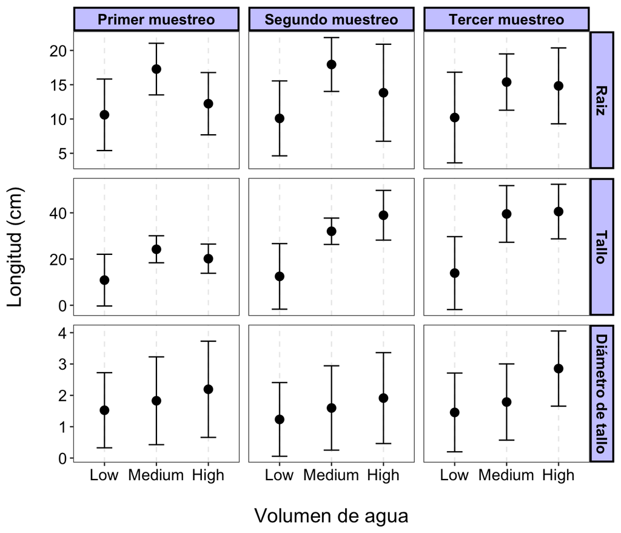

```r
## defino cómo se llamaroon los muestreos y las variables en facet_grid()
    sampling <- c("Primer muestreo", "Segundo muestreo", "Tercer muestreo")
    names (sampling) <- c("1", "2", "3")

    varresp <- c("Tallo", "Raiz", "Diámetro de tallo")
    names(varresp) <- c("tallo", "raiz", "tallodiam")

## filtramos biomasa
filter_1 <- data_statistics %>%
    filter(variable %in% c("tallo", "raiz", "tallodiam"))

## filtramos raiz

## Biomasa aérea y radicular
ggplot(data = filter_1, aes (x = factor(humedad, levels = c("low", "medium", "high")), y = value)) +
    geom_point(size = 3) +
    geom_errorbar(aes(ymin = value - sd, ymax = value + sd), color = "black", size = 0.5, width = 0.3) +
    scale_y_continuous(name = "Longitud (cm)\n") +
    scale_x_discrete(name = "\nVolumen de agua",
             limits = c("low", "medium", "high"),
             labels = c("low" = "Low", "medium" = "Medium", "high" = "High")) +
    facet_grid(cols = vars(muestreo),
           rows = vars(variable),
           scales = "free_y",
           labeller = labeller(muestreo = sampling, variable = varresp)) +
    theme_bw() +
    theme(legend.position = "bottom",
          ## text format
          text = element_text(size = 16, colour = "black"),
          axis.text = element_text(color = "black"),
          ## labels of facet_grid()
          strip.text.x = element_text(size = 12, color = "black", face = "bold"),
          strip.text.y = element_text(size = 12, color = "black", face = "bold"),
          strip.background = element_rect(color="black", fill="#CCCCFF", size=1.5, linetype="solid"),
          ## space between panes
          panel.spacing = unit(0.5, "lines"),
          #gridlines into the plot
          panel.grid.minor = element_blank(),
          panel.grid.major.y = element_blank(),
          panel.grid.major.x = element_line(linetype = "dashed"))
```

Posteiormente, graficamos las variables restantes: `biomasa aérea` y `biomasa radicular`, ambos con la unidad de medida `gramos` (g)

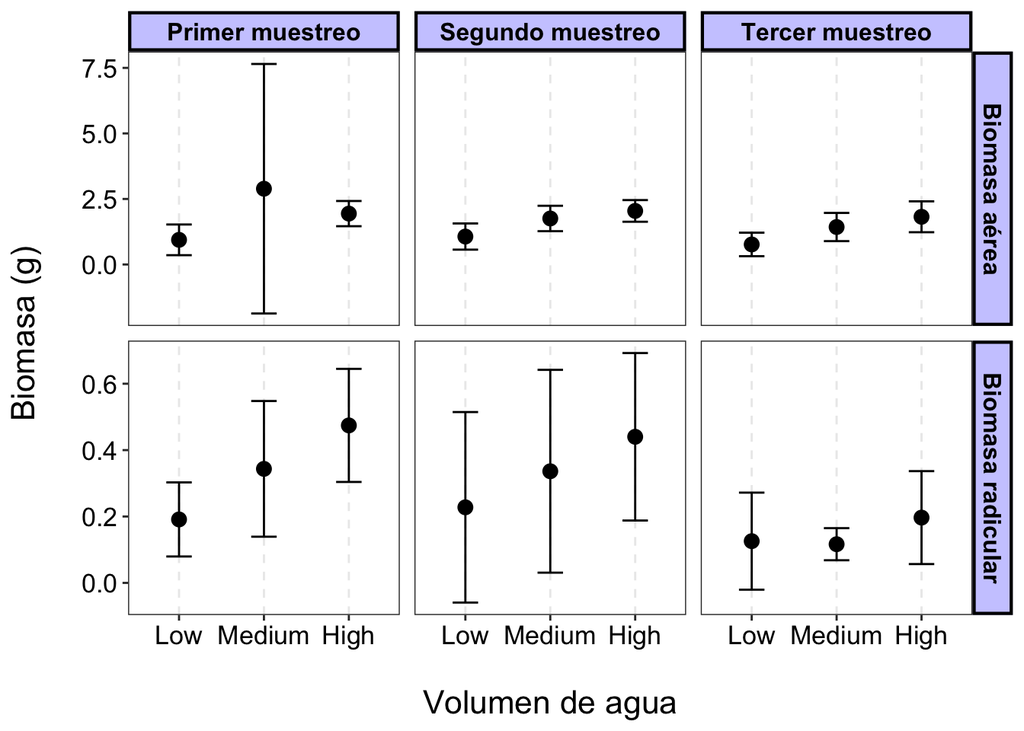

```r
## defino cómo se llamaroon los muestreos y las variables en facet_grid()
    biomasa <- c("Biomasa aérea", "Biomasa radicular")
    names(biomasa) <- c("bioma", "biomr")

## filtramos biomasa
filter_2 <- data_statistics %>%
    filter(variable %in% c("biomr", "bioma"))

## Biomasa aérea y radicular
ggplot(data = filter_2, aes (x = factor(humedad, levels = c("low", "medium", "high")), y = value)) +
    geom_point(size = 3) +
    geom_errorbar(aes(ymin = value - sd, ymax = value + sd), color = "black", size = 0.5, width = 0.3) +
    scale_y_continuous(name = "Biomasa (g)\n") +
    scale_x_discrete(name = "\nVolumen de agua",
             limits = c("low", "medium", "high"),
             labels = c("low" = "Low", "medium" = "Medium", "high" = "High")) +
    facet_grid(cols = vars(muestreo),
           rows = vars(variable),
           scales = "free_y",
           labeller = labeller(muestreo = sampling, variable = biomasa)) +
    theme_bw() +
    theme(legend.position = "bottom",
          ## text format
          text = element_text(size = 16, colour = "black"),
          axis.text = element_text(color = "black"),
          ## labels of facet_grid()
          strip.text.x = element_text(size = 12, color = "black", face = "bold"),
          strip.text.y = element_text(size = 12, color = "black", face = "bold"),
          strip.background = element_rect(color="black", fill="#CCCCFF", size=1.5, linetype="solid"),
          ## space between panes
          panel.spacing = unit(0.5, "lines"),
          #gridlines into the plot
          panel.grid.minor = element_blank(),
          panel.grid.major.y = element_blank(),
          panel.grid.major.x = element_line(linetype = "dashed"))
```

Finalmente, graficamos el número de hojas.

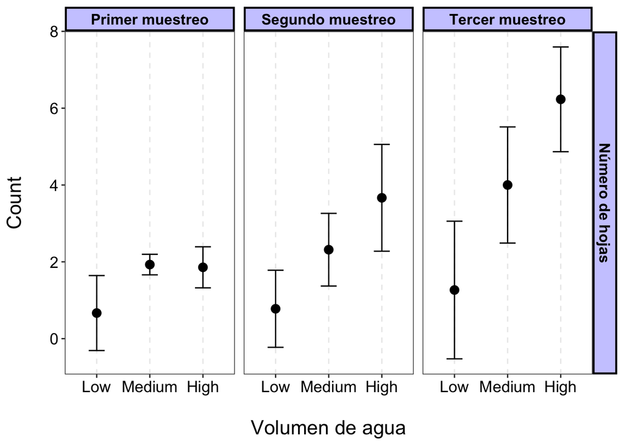

```r
## defino cómo se llamaroon los muestreos y las variables en facet_grid()
    hojas <- c("Número de hojas")
    names(hojas) <- c("hojas")

## filtramos raiz

## Biomasa aérea y radicular
ggplot(data = subset(data_statistics, variable == "hojas"), aes (x = factor(humedad, levels = c("low", "medium", "high")), y = value)) +
    geom_point(size = 3) +
    geom_errorbar(aes(ymin = value - sd, ymax = value + sd), color = "black", size = 0.5, width = 0.3) +
    scale_y_continuous(name = "Count\n") +
    scale_x_discrete(name = "\nVolumen de agua",
             limits = c("low", "medium", "high"),
             labels = c("low" = "Low", "medium" = "Medium", "high" = "High")) +
    facet_grid(cols = vars(muestreo),
           rows = vars(variable),
           scales = "free_y",
           labeller = labeller(muestreo = sampling, variable = hojas)) +
    theme_bw() +
    theme(legend.position = "bottom",
          ## text format
          text = element_text(size = 16, colour = "black"),
          axis.text = element_text(color = "black"),
          ## labels of facet_grid()
          strip.text.x = element_text(size = 12, color = "black", face = "bold"),
          strip.text.y = element_text(size = 12, color = "black", face = "bold"),
          strip.background = element_rect(color="black", fill="#CCCCFF", size=1.5, linetype="solid"),
          ## space between panes
          panel.spacing = unit(0.5, "lines"),
          #gridlines into the plot
          panel.grid.minor = element_blank(),
          panel.grid.major.y = element_blank(),
          panel.grid.major.x = element_line(linetype = "dashed"))
```

## 4. ANÁLISIS DE VARIANZA UNA VIA (anova one way) Y COMPARACIOÓN MÚLTIPLE DE MEDIAS (TUKEY TEST): empleando *loop* `for i`

Para realizar el análisis de varianza y la comparación múltiple de medias de forma iterativa para cada variable de respuesta, necesitamos crear una función que realice la operación de la función `aov()` sobre cada variable que necesitemos evaluar.

Primero definimos esa función. Para esto, se modificó el código publicado en https://stackoverflow.com/questions/61106658/one-way-anova-for-loop-how-do-i-iterate-through-multiple-columns-of-a-dataframe:

```r
## source the function:
aovloop <- function (df = data, factor = x, startvariable = z) {
    for(i in startvariable:ncol(df))
{
    ## extraigo los nombres de las variables, o columnas
    # to print each ROI at the top of each ANOVA summary
    column <- names(df[i])

    # do the anova for each variable
    # Each ANOVA test iterating through each column of my dataframe
    # summarize each ANOVA in a table
    avz <- summary(aov(df[,i] ~ df[,factor], data = df))

    ## aquí determino mi poshoc para cada columna
    tukeyavz<- TukeyHSD(aov(df[,i] ~ df[,factor], data = df))

    # print all columnames and anova summaries
        print(column)
        print(avz)
        print(tukeyavz)
    }
}
```

Posteriormente, aplicamos la función a nuestra base de datos original, i.e., *data*, cuyo formato, recordemos, está a como fue cargado originalmente (también conocido como `wide-format`).

La funcion requiere tres argumentos para funcionar: `aovloop(df, factor, startvariable)`, donde:

- `df` = nuestra base de datos
- `factor` = número de columna del factor o variable independiente, es decir, *humedad*.
- `startvariable` = número de columna inicial de las variables de respuesta, es decir, *tallo*, lo que es lo mismo, la columna no. 8.

```r
## filtramos las filas (u observaciones) con NA o celdas vacias
dataf <- data %>%
    drop_na()

## cargamos la función: aovloop
source('../scripts//aovloop.R')

## aplicamos la función: se imprime en pantalla solamente
aovloop(df = dataf[,-14], factor = 3, startvariable = 8)
```

```
## [1] "tallo"
##               Df Sum Sq Mean Sq F value             Pr(>F)
## df[, factor]   2  13422    6711    42.7 0.0000000000000032 ***
## Residuals    141  22177     157
## ---
## Signif. codes:  0 '***' 0.001 '**' 0.01 '*' 0.05 '.' 0.1 ' ' 1
##   Tukey multiple comparisons of means
##     95% family-wise confidence level
##
## Fit: aov(formula = df[, i] ~ df[, factor], data = df)
##
## $`df[, factor]`
##                diff     lwr     upr  p adj
## low-high    -21.266 -27.330 -15.203 0.0000
## medium-high  -1.675  -7.739   4.389 0.7902
## medium-low   19.591  13.528  25.655 0.0000
##
## [1] "raiz"
##               Df Sum Sq Mean Sq F value      Pr(>F)
## df[, factor]   2   1068     534    19.1 0.000000045 ***
## Residuals    141   3936      28
## ---
## Signif. codes:  0 '***' 0.001 '**' 0.01 '*' 0.05 '.' 0.1 ' ' 1
##   Tukey multiple comparisons of means
##     95% family-wise confidence level
##
## Fit: aov(formula = df[, i] ~ df[, factor], data = df)
##
## $`df[, factor]`
##               diff     lwr     upr  p adj
## low-high    -3.490 -6.0442 -0.9349 0.0043
## medium-high  3.179  0.6245  5.7338 0.0104
## medium-low   6.669  4.1141  9.2234 0.0000
##
## [1] "bioma"
##               Df Sum Sq Mean Sq F value Pr(>F)
## df[, factor]   2     36    18.1    6.96 0.0013 **
## Residuals    141    366     2.6
## ---
## Signif. codes:  0 '***' 0.001 '**' 0.01 '*' 0.05 '.' 0.1 ' ' 1
```

[output cut: 46 more lines]

```
##               Df Sum Sq Mean Sq F value             Pr(>F)
## df[, factor]   2    211   105.7    41.5 0.0000000000000065 ***
## Residuals    141    359     2.5
## ---
## Signif. codes:  0 '***' 0.001 '**' 0.01 '*' 0.05 '.' 0.1 ' ' 1
##   Tukey multiple comparisons of means
##     95% family-wise confidence level
##
## Fit: aov(formula = df[, i] ~ df[, factor], data = df)
##
## $`df[, factor]`
##               diff    lwr     upr  p adj
## low-high    -2.937 -3.709 -2.1664 0.0000
## medium-high -1.104 -1.875 -0.3331 0.0026
## medium-low   1.833  1.062  2.6044 0.0000
```

```r
## tomamoos la salida y la guardamos en un archivo de texto
anova_and_tukey_loop <- capture.output(aovloop(df = dataf[,-14], factor = 3, startvariable = 8)
)

write.table(x = anova_and_tukey_loop, quote = F, file = '../outputs/anovatukeyloop.txt')
```

## 5. ANOVA + RANDOM EFFECT VARIABLE (EFECTO DEL TÉCNICO)

### bloqueando por “equipo”: sí hubo efecto

Recordemos que una variable no tomada en cuenta durante el análisis de varianza fue el “experimentador” o “técnico”. Esta variable se puede tomar en cuenta empleando un análisis de varianza con bloque incluyendo una variable `random effect` (https://rcompanion.org/handbook/I_07.html).

```r
## determinar anova+random effect de cada variable
library(lme4)
library(lmerTest)

tall_model = lme4::lmer(tallo ~ humedad + (1|team),
             data=data,
             REML=TRUE)

anova(tall_model)
```

```
## Analysis of Variance Table
##         npar Sum Sq Mean Sq F value
## humedad    2  12947    6474    51.8
```

```r
rand(tall_model)
```

```
## ANOVA-like table for random-effects: Single term deletions
##
## Model:
## tallo ~ humedad + (1 | team)
##            npar logLik  AIC  LRT Df Pr(>Chisq)
## <none>        5   -562 1135
## (1 | team)    4   -573 1155 21.9  1  0.0000029 ***
## ---
## Signif. codes:  0 '***' 0.001 '**' 0.01 '*' 0.05 '.' 0.1 ' ' 1
```

Los resultados muestran que existieron diferencias en las variables de respuesta debido a la variable `team`; es decir, hubo diferencias significativas en las mediciones debido al experimentador.

### bloqueando por varidad: la variedad no tuvo efecto

```r
## determinar anova+random effect de cada variable

tall_var = lme4::lmer(tallo ~ humedad + (1|variedad),
             data=data,
             REML=TRUE)

anova(tall_var)
```

```
## Analysis of Variance Table
##         npar Sum Sq Mean Sq F value
## humedad    2  13241    6621    44.3
```

```r
rand(tall_var)
```

```
## ANOVA-like table for random-effects: Single term deletions
##
## Model:
## tallo ~ humedad + (1 | variedad)
##                npar logLik  AIC  LRT Df Pr(>Chisq)
## <none>            5   -572 1154
## (1 | variedad)    4   -573 1155 2.53  1       0.11
```

### bloqueando por fertilizante: sí tuvo efecto

```r
## determinar anova+random effect de cada variable
tall_modf = lme4::lmer(tallo ~ humedad + (1|fertilizer),
             data=data,
             REML=TRUE)

anova(tall_modf)
```

```
## Analysis of Variance Table
##         npar Sum Sq Mean Sq F value
## humedad    2  13015    6508    48.6
```

```r
rand(tall_modf)
```

```
## ANOVA-like table for random-effects: Single term deletions
##
## Model:
## tallo ~ humedad + (1 | fertilizer)
##                  npar logLik  AIC LRT Df Pr(>Chisq)
## <none>              5   -564 1139
## (1 | fertilizer)    4   -573 1155  18  1   0.000022 ***
## ---
## Signif. codes:  0 '***' 0.001 '**' 0.01 '*' 0.05 '.' 0.1 ' ' 1
```